# Text Clustering

Kevin Larrabee kevin.s.larrabee.mil@mail.mil

May 20, 2016

## Introduction

Text analysis leverages the abundance of digital documents to improve perspective, clarity, and relationships. It bridges the gap between the written word and quanatatitive techniques. Text analysis is difficult and assumptions have to be made with the data to make inferences about relationships within the data.

### Finding Your Data

Text data is everywhere. Consumer opinion, news outlets, intelligence reporting, and strategy opinions are some examples of where text data can be found.

### Data

Install and load all of the packages below and set the directory to wherever you have the articles saved. From there you can build your Corpus of articles. The tm package provides the horsepower to start the text munging process.

```r
library(htmlwidgets)
library(vegan)
library(tm)
library(ggplot2)
library(plyr)
library(dplyr)
library(rowr)
library(ggplot2)
library(wordcloud)
library(digest)
library(edgebundleR)
library(textir)
library(cluster)
library(chorddiag)
library(networkD3)
```

```r
## Point to all of the articles
source.name<-file.path("C:/Users/kevin.s.larrabee/Desktop/Articles/")
corp<-NULL
##Build a Corpus of all articles
corp<-Corpus(DirSource(source.name))
```

```r
## Preprocessing to convert to useable format
corp <- tm_map(corp, content_transformer(tolower))
corp <- tm_map(corp, content_transformer(removePunctuation))
corp <- tm_map(corp, content_transformer(removeWords), stopwords("english"))
corp <- tm_map(corp, content_transformer(removeNumbers))
```

```r
## Stem document, truncate words
corp<-tm_map(corp, content_transformer(stemDocument))

## Change preprocessed documents into text documents
corp <- tm_map(corp, PlainTextDocument)

## Create document term matrix, essentially all words that are in the corpus by document
dtm<-DocumentTermMatrix(corp)
```

The Document Term Matrix provides the frequency of words by source name. Once converted into a matrix, you can then start leveraging different techniques to visualize converging and diverging word groupings.

```r
## Turn the DTM into a matrix to start understanding your data
mat<-as.matrix(dtm)
dim(mat)
```

```
## [1]   54 6816
```

```r
## Attach the article names to the matrix
rownames(mat)<-art.name

mat<-mat[,colSums(mat)>5]
dim(mat)
```

```
## [1]  54 968
```

```r
## Remove Spurious Words
mat<-mat[,-c(1:3)]
```

The frequency matrix provides the counts of the unique words per article. The frequencies may change the distance calculations when comparing article to article. In order to do some sensitivity analysis, we turned the matrix into a normalized matrix and a term frequency inverse document frequency. Both scale the frequencies into densities per the article and in relationship to the entire group of documents. We will focus our analysis on the normalized matrix, because it emphasizes the word important to each article regardless of the size of the article.

```r
## Frequency Matrix
freq.mat<-mat
## Normalized Matrix
datnorm <- freq.mat/rowSums(freq.mat)
## IDF
idf<-tfidf(freq.mat)
```

### Clustering

The normal progression to text analysis is clustering. Understand how the articles fit together based on the word contained in the articles is important. Clustering is a very broad technique, so we will focus on 2 types: hierarchical and kmeans.

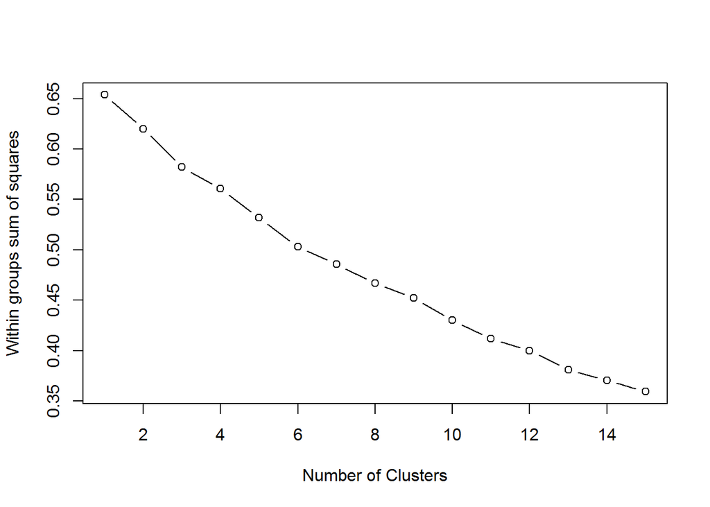

```r
wss <- (nrow(datnorm)-1)*sum(apply(datnorm,2,var))
for (i in 2:15) wss[i] <- sum(kmeans(datnorm,
                                     centers=i)$withinss)
plot(1:15, wss, type="b", xlab="Number of Clusters",
     ylab="Within groups sum of squares")
```

Hierarchical clustering is conducted using a variety of distance calculations, which then are linked together to find groupings. Some of the most popular distance metrics are Euclidean, Manhattan, and Canberra. The linkage criterion determines the distance between sets of observations as a function of the pairwise distances between observations. Some of the most common linkage criterion are Wards (the decrease in variance for the cluster being merged), mean, and centroid. Below we use 10 clusters with a Manhattan distance and Wards linkage criterion to find the clusters.

```r
## START FUNCTION
clusters<-function(data=datnorm,k=10,method="manhattan"){
  qq3<-hclust(dist(data, method=method),"ward.D")

  groups<-data.frame(cutree(qq3,k=10))
  names(groups)[1]<-"Cluster"
  groups$SourceName<-art.name
  groups<-groups[order(groups$Cluster),]
  groups
}
## END FUNCTION

cc<-clusters(datnorm)
dd<-clusters(idf)
```

From there we can build the clusters and then visualize the dendrogram through the D3network package built into R.

```r
## Function to Build Cluster Object
clust_obj<-function(data=datnorm){
  qq3<-hclust(dist(data, method="manhattan"),"ward.D")
  qq3
}

fit_a<-clust_obj(datnorm)
fit_d<-clusters(idf)

dendroNetwork(fit_a,  height = 1000, width = 2000, fontSize = 6,
              textColour = c("brown","light blue","pink","gray","tan","red", "blue", "orange","black","green")[cutree(fit_a, 10)],
              treeOrientation = "horizontal",zoom = TRUE,linkType = "elbow",nodeStroke="grey")
```

[interactive chart not shown]

The kmeans algorithm attempts to minimize within-cluster variance. This technique is an alternative to the hierarchical clustering techniques.

```r
##### K-means Clustering
library(fpc)

d<-dist(mat,method="euclidian")
kfit<-kmeans(d,10)

kmeans<-data.frame(kfit$cluster)
kmeans$SourceName<-rownames(kmeans)
names(kmeans)[1]<-"Cluster"
kmeans<-kmeans[order(kmeans$kfit.cluster),]
```

So what about the clusters are so interesting, what makes them unique compared to the rest of the clusters.

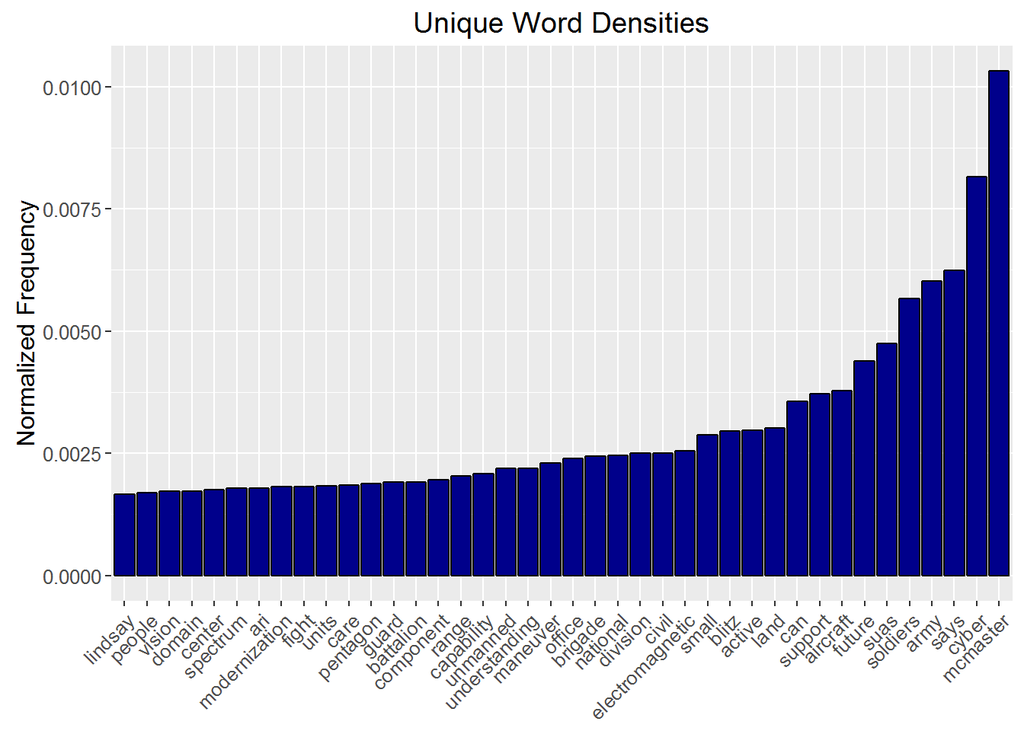

```r
unique<-function(clt=1){

q<-count(rownames(subset(kmeans,Cluster==clt)))
hh<-NULL
for (i in (1:q)){
aa[i]<-which(art.name==rownames(subset(kmeans,Cluster==clt))[i])
hh<-c(aa[i],hh)
hh
}
clus.avg<-apply(datnorm[hh,],2,mean)
notclus.avg<-apply(datnorm[-aa,],2,mean)
unique<-clus.avg-notclus.avg
unique.sort<-unique[order(unique)]
unique.sort<-data.frame(tail(unique.sort,40))
names(unique.sort)<-"Diff";unique.sort$Word<-rownames(unique.sort)

## Plot the Words
p<-ggplot(unique.sort,aes(reorder(Word,Diff),Diff))
p<-p+geom_bar(fill="dark blue",color="black",stat="identity")+xlab(NULL)+ylab("Normalized Frequency")+labs (title = "Unique Word Densities")
p<-p+theme(text = element_text(size=12),axis.text.x=element_text(angle=45,hjust=1))
p
}
ww<-unique(clt=6)
print(ww)
```

Understand the agreement between manhattan distance and Kmeans clustering

```r
#Source is the Articles
# Understand the agreement between manhattan distance and Kmeans clustering
combo<-rbind(cc,kmeans)

src <- combo[,2]
target <- combo[,1]

networkData <- data.frame(src, target)
```

Plot nice visual of the articles that are associated with the kmeans cluster

```r
simpleNetwork(data.frame(kmeans[,2], kmeans[,1]),zoom=TRUE)
```

[interactive chart not shown]

Visualize the confusion matrix between kmeans and Manhattan/Ward clusters

```r
simpleNetwork(networkData,zoom=TRUE)
```

[interactive chart not shown]

### Jaccard Scores

Jaccard score or coefficient is a statistic used for comparing the similarity and diversity of sample sets. The Jaccard coefficient measures similarity between finite sample sets, set intersection divided by the size of the union of the sample sets. Can be used to measure the normalized matrix, binary, or frequency matrices. Utilize the vegan package to do large scale jaccard score calculations, this gives the dissimiliarity, so make sure to subtract by one to get similiarities.

```r
# Vegdist is a dissimiliarity score
jac<-as.matrix(vegdist(datnorm, method = "jaccard"))
dim(jac)
```

```
## [1] 54 54
```

```r
# Subtract by one to get similiarity score
ones<- matrix(rep(1, nrow(datnorm)+ nrow(datnorm)),
                 byrow = TRUE,
                 nrow = nrow(datnorm),nrow(datnorm))
dim(ones)
```

```
## [1] 54 54
```

```r
sim<-ones-jac
# Change the threshold to see extreme similiarities
sim<-ifelse(sim>.15,sim,0)
diag(sim)<-0

# Plot the data on a chord diagram showing the highest associations
chorddiag(sim, groupnamePadding = 40,groupnameFontsize = 10)
```

[interactive chart not shown]

### Conclusion

Text Analysis is extremely versatile and helpful to aggregate documents to gain perspective. Word density distance calculations leverage the power of set theory and distance calculations to arrive at new understandings. Visualizations amplify the power of clustering and Jaccard scores to communicate to the user valuable insights.